# Predictive Modeling of Proper Exercise Form

Miadad Rashid

Thursday, September 18, 2014

#### HAR (Human Activity Recognition) Project

In the following, we will be creating a predictive model of the [Weight Lifting Exercises Dataset](http://groupware.les.inf.puc-rio.br/static/WLE/WearableComputing_weight_lifting_exercises_biceps_curl_variations.csv) found on the page linked above. This research aimed to predict the level of how proper individuals were performing an exercise. The outcome was classified between A-E and is located in the **classe** column. I will walk you through my intuition for how I chose the variables that the eventual predictive model was based upon and why I chose the particular learning algorithm to create the model. A couple of things to note before proceeding.

- There are two datasets we are going to download; **pml-training.csv** and **pml-testing.csv**, which will be saved to **dataTrain** and **dataTest**, respectively.
- **dataTrain** has the outcome variable, **classe**, which we will be trying to predict in **dataTest**.
- **dataTest** does not include the outcome variable in order to not introduce bias or help influence any readjustments to the predictive model.
- **dataTrain** will be divided into **training** and **testing** sets. All the preprocessing/slicing/manipulating will be done on the **training** set.
- The final predictive model will also be based on **training** set.
- The **testing** set will be used as a preliminary testing ground to base the accuracy of the model and to make necessary readjustments before applying the predictive model to the **dataTest** dataset.

##### Downloading and Slicing the data

```r
set.seed(47)  ## Seed selection for reproducibility
require(caret)

dataTrain <- read.csv('http://d396qusza40orc.cloudfront.net/predmachlearn/pml-training.csv')  ## Training dataset
dataTest <- read.csv('http://d396qusza40orc.cloudfront.net/predmachlearn/pml-testing.csv')  ## Testing dataset
```

##### Partitioning the dataTrain into the training and testing Datasets

```r
## Dividing the training dataset 70/30 by the *classe* variable

inTrain <- createDataPartition(y = dataTrain$classe, p = 0.7, list = F)

training <- dataTrain[inTrain,]
testing <- dataTrain[-inTrain,]
```

##### Preprocessing

###### We are going first look for missing values within the data and see if we can either impute or remove columns that would only introduce un-needed influence upon the final model.

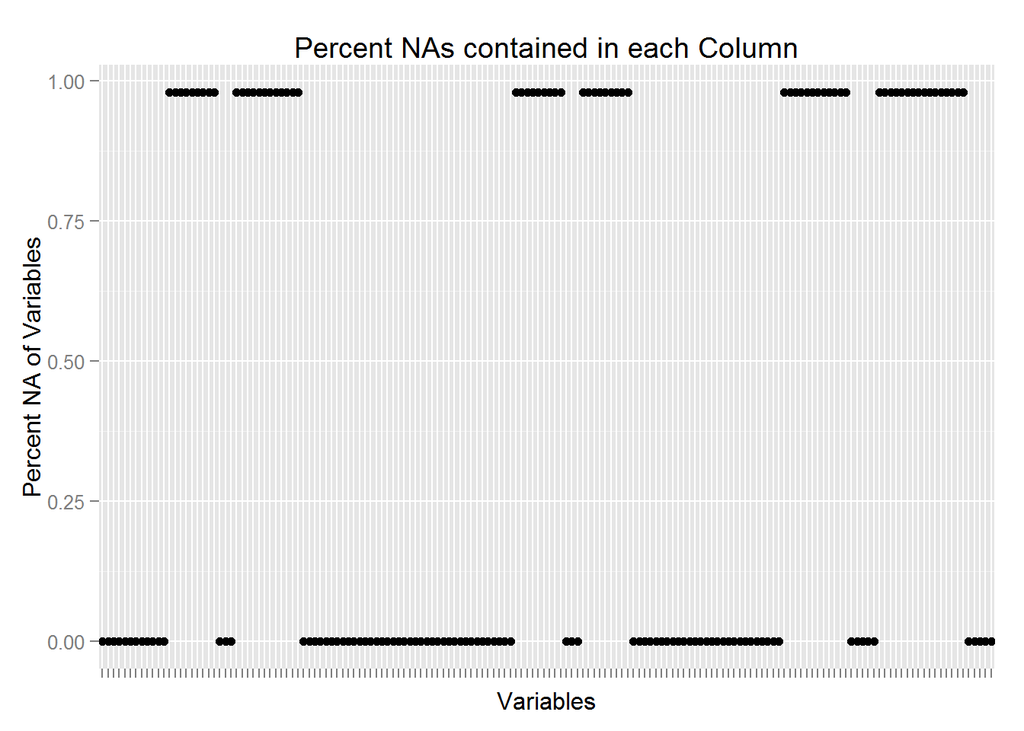

```r
percentNa <- colSums(is.na(dataTrain))/length(dataTrain$classe)
percentNa <- data.frame('Variables' = names(training), 'Percent' = percentNa)
row.names(percentNa) <- NULL
q <- qplot(data = percentNa, y = Percent, x = Variables, main = 'Percent NAs contained in each Column')
q + theme(axis.text.x = element_blank()) + ylab('Percent NA of Variables')
```

```r
max(percentNa$Percent)
```

```
## [1] 0.9793
```

- As you can see, either the variables contain no NAs, or contain close to all NAs (~98%).
- Imputing the missing values of NAs would introduce major bias and speculation into the data. We instead will chose to remove those columns which have NAs

```r
training <- training[,complete.cases(t(training))] ## training will only include complete columns
```

###### Now we will remove columns that have close to zero variance. Columns that have close to no variance offer no relevant information when creating a predicitive model since their data is close to constant and our outcome is not.

```r
training <- training[,-nearZeroVar(training)]
```

###### Visual examination of the columns

```r
names(training)
```

```
##  [1] "X"                    "user_name"            "raw_timestamp_part_1"
##  [4] "raw_timestamp_part_2" "cvtd_timestamp"       "num_window"
##  [7] "roll_belt"            "pitch_belt"           "yaw_belt"
## [10] "total_accel_belt"     "gyros_belt_x"         "gyros_belt_y"
## [13] "gyros_belt_z"         "accel_belt_x"         "accel_belt_y"
## [16] "accel_belt_z"         "magnet_belt_x"        "magnet_belt_y"
## [19] "magnet_belt_z"        "roll_arm"             "pitch_arm"
## [22] "yaw_arm"              "total_accel_arm"      "gyros_arm_x"
## [25] "gyros_arm_y"          "gyros_arm_z"          "accel_arm_x"
## [28] "accel_arm_y"          "accel_arm_z"          "magnet_arm_x"
## [31] "magnet_arm_y"         "magnet_arm_z"         "roll_dumbbell"
## [34] "pitch_dumbbell"       "yaw_dumbbell"         "total_accel_dumbbell"
## [37] "gyros_dumbbell_x"     "gyros_dumbbell_y"     "gyros_dumbbell_z"
## [40] "accel_dumbbell_x"     "accel_dumbbell_y"     "accel_dumbbell_z"
## [43] "magnet_dumbbell_x"    "magnet_dumbbell_y"    "magnet_dumbbell_z"
## [46] "roll_forearm"         "pitch_forearm"        "yaw_forearm"
## [49] "total_accel_forearm"  "gyros_forearm_x"      "gyros_forearm_y"
## [52] "gyros_forearm_z"      "accel_forearm_x"      "accel_forearm_y"
## [55] "accel_forearm_z"      "magnet_forearm_x"     "magnet_forearm_y"
## [58] "magnet_forearm_z"     "classe"
```

- We only want data that directly determine the individual’s performance in the exercise
- variables such as the individuals name and timestamps, although may follow some correlative pattern with the outcome, does not directly influence exercise performance.
- Columns 1-6 will be removed because of the ability to influence the predictive model yet not being a direct influence on exercise performance.

```r
training <- training[,-c(1:6)]
dim(training) ## Final dimensions of the training set used for predictive modeling
```

```
## [1] 13737    53
```

##### Model Fitting with K-Folds

###### We will use k-folds to create partitions of the **training** set. Then we create a model from the first fold and apply it to the subsequent folds to cross-validate. The eventual accuracy will be averages of the individual confusion matrices produced from each fold.

1. We will be using a random forest algorithm
2. Creating 10 K-folds then modeling.
3. Apply model to the remaining 9 folds.
4. Calculating accuracy with Confusion Matrices.
5. Creating 5 K-fold then modeling.
6. Apply model to the remaining 4 folds then to the 10 folds created prior

Two Hypothesis

1. Lowering the size of K will increase the accuracy of the model
2. A model created from a larger dataset, when predicting a smaller dataset, will be more accurate

```r
fold10 <- createFolds(y = training$classe, k = 10)
fit1 <- train(classe~., method = 'rf', data = training[fold10[[1]],])
results <- data.frame(t(sapply(2:10, function(x){
    confusionMatrix(training[fold10[[x]],]$classe, predict(fit1, training[fold10[[x]],]))$overall
})))$Accuracy
mean(results) ## Average of the accuracy predicitons not including the fold the model was created from
```

```
## [1] 0.9392
```

- We are achieving a ~94% accuracy across the remaining 9 folds. Now let’s try creating a model from a larger dataset with 5 fold breaks.

```r
fold5 <- createFolds(y = training$classe, k = 5)
fit2 <- train(classe~., method = 'rf', data = training[fold5[[1]],])
results <- data.frame(t(sapply(2:5, function(x){
    confusionMatrix(training[fold5[[x]],]$classe, predict(fit2, training[fold5[[x]],]))$overall
})))$Accuracy
mean(results) ## Average of the accuracy predicitons not including the fold the model was created from
```

```
## [1] 0.9568
```

```r
## Now we will apply the new model to the smaller folds and compute average accuracy
results <- data.frame(t(sapply(2:10, function(x){
    confusionMatrix(training[fold10[[x]],]$classe, predict(fit2, training[fold10[[x]],]))$overall
})))$Accuracy
mean(results)
```

```
## [1] 0.9653
```

- As you can see lowering the K-folds and using a larger dataset to model from got us a ~96% accuracy.
- Then applying that model to the smaller folds (k=10) we achieved a ~97% accuracy.

#### Creating the final model and proving accuracy on the testing set. Added Bonus: showing the model prediction on the dataTest set which does not have the outcomes and comparing it to the correct answers.

##### Testing the final model on the testing set.

- Note that the **testing** set came from the original **training** data and has not been altered in any way.

```r
fit3 <- train(classe~., method = 'rf', data = training)
confusionMatrix(testing$classe, predict(fit3, testing))
```

```
## Confusion Matrix and Statistics
##
##           Reference
## Prediction    A    B    C    D    E
##          A 1671    3    0    0    0
##          B   10 1126    3    0    0
##          C    0   10 1013    3    0
##          D    1    0   17  944    2
##          E    0    0    4    2 1076
##
## Overall Statistics
##
##                Accuracy : 0.991
##                  95% CI : (0.988, 0.993)
##     No Information Rate : 0.286
##     P-Value [Acc > NIR] : <2e-16
##
##                   Kappa : 0.988
##  Mcnemar's Test P-Value : NA
##
## Statistics by Class:
##
##                      Class: A Class: B Class: C Class: D Class: E
## Sensitivity             0.993    0.989    0.977    0.995    0.998
## Specificity             0.999    0.997    0.997    0.996    0.999
## Pos Pred Value          0.998    0.989    0.987    0.979    0.994
## Neg Pred Value          0.997    0.997    0.995    0.999    1.000
## Prevalence              0.286    0.194    0.176    0.161    0.183
## Detection Rate          0.284    0.191    0.172    0.160    0.183
## Detection Prevalence    0.284    0.194    0.174    0.164    0.184
## Balanced Accuracy       0.996    0.993    0.987    0.995    0.998
```

After achieving an accuracy of ~99%, we are ready to apply it to the final **dataTest**. The **dataTest** set was not used in anyway to creat the predictive model and the actual answers were acquired after the final submission and correction.

```r
correctAnswers <- c("B","A", "B", "A", "A", "E", "D", "B", "A", "A", "B", "C", "B", "A", "E", "E", "A", "B", "B", "B")  ## Achieved from correct submissions

confusionMatrix(correctAnswers, predict(fit3, dataTest))
```

```
## Confusion Matrix and Statistics
##
##           Reference
## Prediction A B C D E
##          A 7 0 0 0 0
##          B 0 8 0 0 0
##          C 0 0 1 0 0
##          D 0 0 0 1 0
##          E 0 0 0 0 3
##
## Overall Statistics
##
##                Accuracy : 1
##                  95% CI : (0.832, 1)
##     No Information Rate : 0.4
##     P-Value [Acc > NIR] : 1.1e-08
##
##                   Kappa : 1
##  Mcnemar's Test P-Value : NA
##
## Statistics by Class:
##
##                      Class: A Class: B Class: C Class: D Class: E
## Sensitivity              1.00      1.0     1.00     1.00     1.00
## Specificity              1.00      1.0     1.00     1.00     1.00
## Pos Pred Value           1.00      1.0     1.00     1.00     1.00
## Neg Pred Value           1.00      1.0     1.00     1.00     1.00
## Prevalence               0.35      0.4     0.05     0.05     0.15
## Detection Rate           0.35      0.4     0.05     0.05     0.15
## Detection Prevalence     0.35      0.4     0.05     0.05     0.15
## Balanced Accuracy        1.00      1.0     1.00     1.00     1.00
```

# Success!

### The prediction was 100% accurate on the final Data set.